# phyloseq

wentao

2021/5/3

*correspondence: YongXin Liu <YongXin@smu.edu.cn>and Jun Yuan <JunYuan@njau.edu.cn>

## introduction

phyloseq：使用R语言分析微生物群落(microbiome census data) 目前对微生物群落的分析有许多挑战：使用生态学，遗传学，系统发育学，网络分析等方法对不同类型的微生物群落数据进行整合，可视化分析(visualization and testing)。微生物群落数据本身可能来源广泛，例如：人体微生物，土壤，海面及其海水，污水处理厂，工业设施等; 因此，不同来源微生物群落就其实验设计和科学问题可能有非常大的差异。phyloseq软件包是一个对在聚类OTU后的微生物群落（数据包括：OTU表格，系统发育树，OTU注释信息）进行下游系统发育等分析的综合性工具，集成了微生物群落数据导入，存储，分析和出图等功能。该软件包利用R中的许多工具进行生态学和系统发育分析(vegan, ade4, ape, picante)，同时还使用先进/灵活的图形系统（ggplot2）轻松的对系统发育数据绘制发表级别的图表。phyloseq使用S4类的系统将所有相关的系统发育测序数据存储为单个实验级对象，从而更容易共享数据并重现分析。通常，phyloseq寻求促进使用R进行OTU聚类的高通量系统发育测序数据的有效探索和可重复分析。

## pipeline-phyloseq

基于phyloseq分析微生物组数据和传统方式不同，S4对象的使用给phyloseq处理微生物组数据带来了方便，但是也有门槛了，比如构建phyloseq对象。

### 构造phyloseq对象

phyloseq包含五个内容，分别是OTU表格，物种注释表格，样本分组文件，进化树文件和代表序列文件。其中OTU表格和物种注释文件要求格式为矩阵，样本分组文件要求为数据框，进化树格式为RWK，代表序列为fa文件。

下满个构造phyloseq对象。

```r
library(ggplot2)
library(phyloseq)
library(ggClusterNet)# github：taowenmicro/ggCLusterNet
```

### 准备数据-构建phyloseq对象

```r
# metadata = read.delim("https://raw.githubusercontent.com/taowenmicro/R-_function/main/metadata.tsv",row.names = 1)
# otutab = read.delim("https://raw.githubusercontent.com/taowenmicro/R-_function/main/otutab.txt", row.names=1)
# taxonomy = read.table("https://raw.githubusercontent.com/taowenmicro/R-_function/main/taxonomy.txt", row.names=1,header = T)
# tree  = read_tree("https://raw.githubusercontent.com/taowenmicro/R-_function/main/otus.tree")
# library(Biostrings)
# rep = readDNAStringSet("https://raw.githubusercontent.com/taowenmicro/R-_function/main/otus.fa")
#
# ps = phyloseq(sample_data(metadata),
#               otu_table(as.matrix(otutab), taxa_are_rows=TRUE),
#               tax_table(as.matrix(taxonomy)), phy_tree(tree),refseq(rep)
#               )

data(ps)
```

### 对群落数据进行基本描述和分析

```r
#统计OTU数量
ntaxa(ps)
```

```
## [1] 2861
```

```r
# 统计样品数量
nsamples(ps)
```

```
## [1] 18
```

```r
# 查看样品名称
sample_names(ps)[1:5]
```

```
## [1] "KO1" "KO2" "KO3" "KO4" "KO5"
```

```r
# 查看物种分类等级
rank_names(ps)
```

```
## [1] "Kingdom" "Phylum"  "Class"   "Order"   "Family"  "Genus"   "Species"
```

```r
# 查看分组文件表头信息
sample_variables(ps)
```

```
##  [1] "Group"                "Date"                 "Site"
##  [4] "Sequencing"           "Platform"             "Species"
##  [7] "Batch"                "BarcodeSequence"      "LinkerPrimerSequence"
## [10] "ReversePrimer"
```

```r
# 部分可视化OTU表格
otu_table(ps)[1:5, 1:5]
```

```
## OTU Table:          [5 taxa and 5 samples]
##                      taxa are rows
##           KO1  KO2 KO3  KO4  KO5
## ASV_1    1113 1968 816 1372 1062
## ASV_1591   12   10   1   14    3
## ASV_657     5    7   6    9    8
## ASV_28    253  303  54  439  132
## ASV_1717    3    6   0    1    0
```

```r
# 部分可视化tax注释表格
tax_table(ps)[1:5, 1:4]
```

```
## Taxonomy Table:     [5 taxa by 4 taxonomic ranks]:
##          Kingdom    Phylum           Class            Order
## ASV_1    "Bacteria" "Actinobacteria" "Actinobacteria" "Actinomycetales"
## ASV_1591 "Bacteria" "Actinobacteria" "Actinobacteria" "Actinomycetales"
## ASV_657  "Bacteria" "Actinobacteria" "Actinobacteria" "Actinomycetales"
## ASV_28   "Bacteria" "Actinobacteria" "Actinobacteria" "Actinomycetales"
## ASV_1717 "Bacteria" "Actinobacteria" "Actinobacteria" "Actinomycetales"
```

```r
# 查看进化树文件
phy_tree(ps)
```

```
##
## Phylogenetic tree with 2861 tips and 2860 internal nodes.
##
## Tip labels:
##   ASV_1, ASV_1591, ASV_657, ASV_28, ASV_1717, ASV_2407, ...
##
## Rooted; includes branch lengths.
```

### 数据清洗和标准化

```r
#-基于样本-----去除序列量比较少的样本
ps <- prune_samples(sample_sums(ps) >=2000,ps);ps
```

```
## phyloseq-class experiment-level object
## otu_table()   OTU Table:         [ 2861 taxa and 18 samples ]
## sample_data() Sample Data:       [ 18 samples by 10 sample variables ]
## tax_table()   Taxonomy Table:    [ 2861 taxa by 7 taxonomic ranks ]
## phy_tree()    Phylogenetic Tree: [ 2861 tips and 2860 internal nodes ]
```

```r
#--基于样本----去除低丰度OTU，这里去除全部read为0的OTU
ps = filter_taxa(ps, function(x) sum(x ) > 0 , TRUE)
```

### alpha多样性分析

```r
p0 <- plot_richness(ps, x="Group", color="Group", measures=c("Chao1", "Observed"))

p0$layers[[2]] = NULL # 去除误差线
# 添加箱型图
p0 <- p0  + geom_boxplot() + theme_bw()

ggsave("./Fig1_alpha.png",p0,width = 6,height = 4)
```

### beta多样性-排序分析可视化

```r
ps_rela = transform_sample_counts(ps, function(x) 1E6 * x/sum(x))
ord <- ordinate(ps_rela, "NMDS", "bray")
```

```
## Square root transformation
## Wisconsin double standardization
## *** Solution reached
```

```r
ord
```

```
##
## Call:
## metaMDS(comm = veganifyOTU(physeq), distance = distance)
##
## global Multidimensional Scaling using monoMDS
##
## Data:     wisconsin(sqrt(veganifyOTU(physeq)))
## Distance: bray
##
## Dimensions: 2
## Stress:     0.07711868
## Stress type 1, weak ties
## Two convergent solutions found after 20 tries
## Scaling: centring, PC rotation, halfchange scaling
## Species: expanded scores based on 'wisconsin(sqrt(veganifyOTU(physeq)))'
```

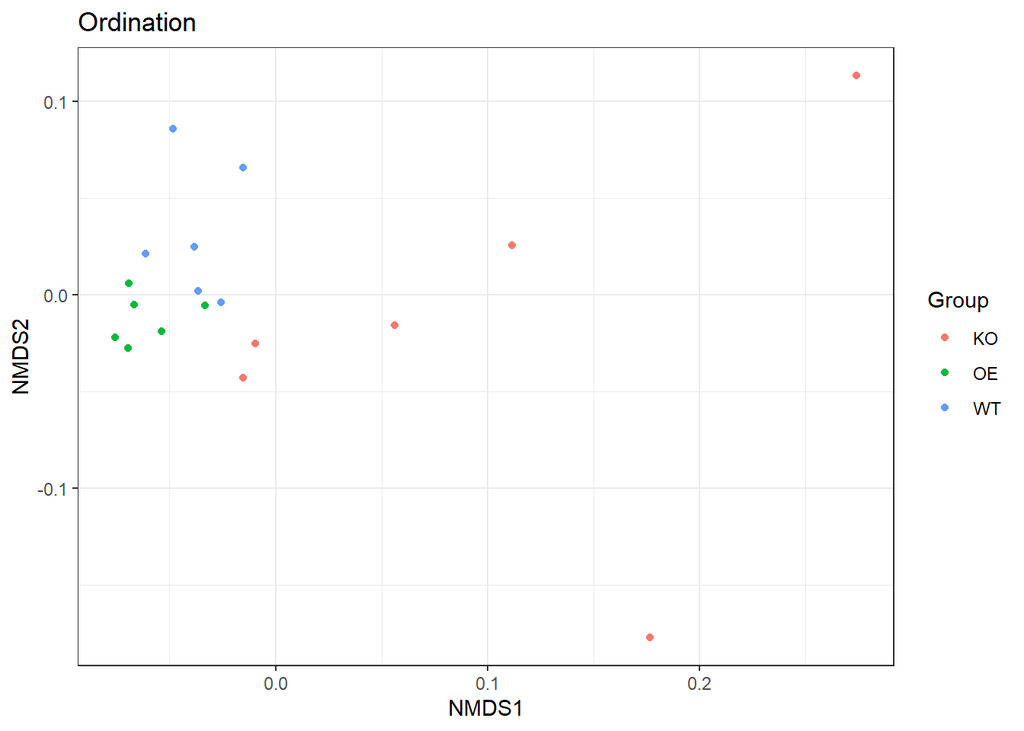

```r
p1 = plot_ordination(ps, ord, type="samples", color="Group", title="Ordination") + theme_bw()
p1
```

```r
ggsave("./Fig2_ordination.png",p1,width = 5,height = 5)
```

### 微生物物种组成分析

堆叠柱状图在不同分类水平按照不同分组展示微生物的丰度信息，遗憾的是这个函数如果可以展示高丰度的几十个微生物，并且将其他微生物合并在一起作为others就好了。

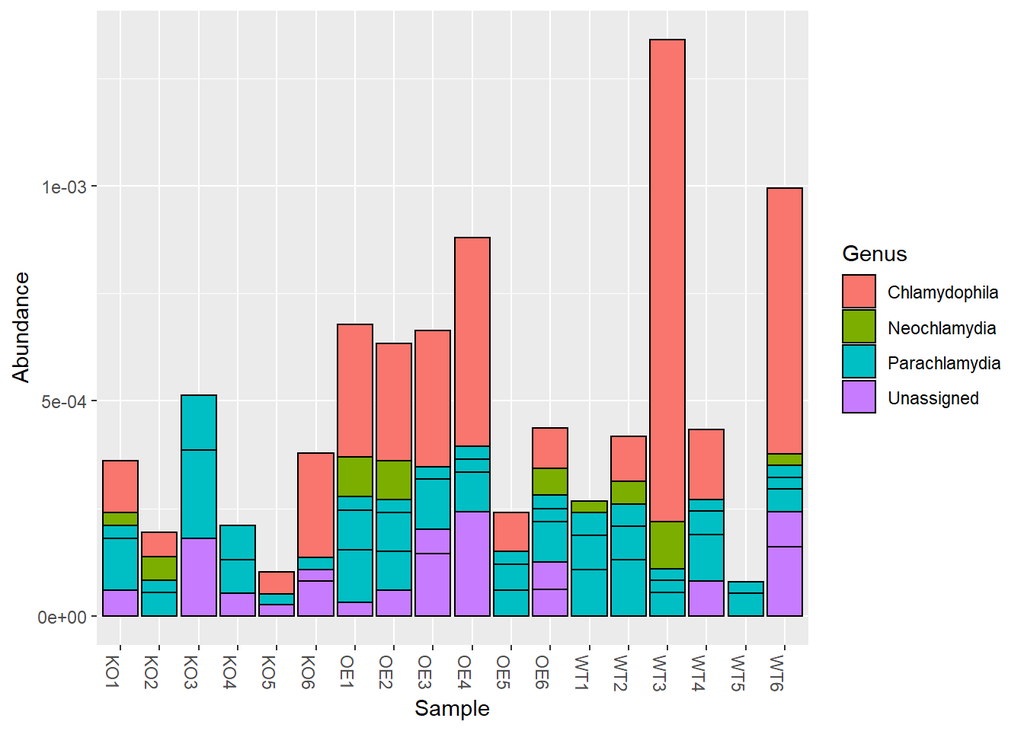

```r
ps_rela = transform_sample_counts(ps, function(x) x/sum(x))
#--相对丰都标准化后展示全部OTU-使用门水平着色。
p2 <- plot_bar(ps_rela, fill="Phylum") + theme_bw()
#--展示部分感兴趣的微生物
gp.ch = subset_taxa(ps_rela, Phylum == "Chlamydiae")
plot_bar(gp.ch, fill="Genus")
```

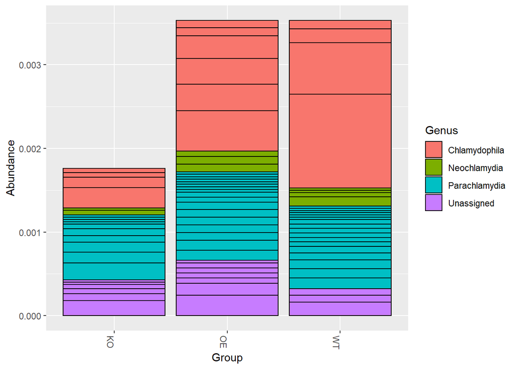

```r
plot_bar(gp.ch, x="Group", fill="Genus")
```

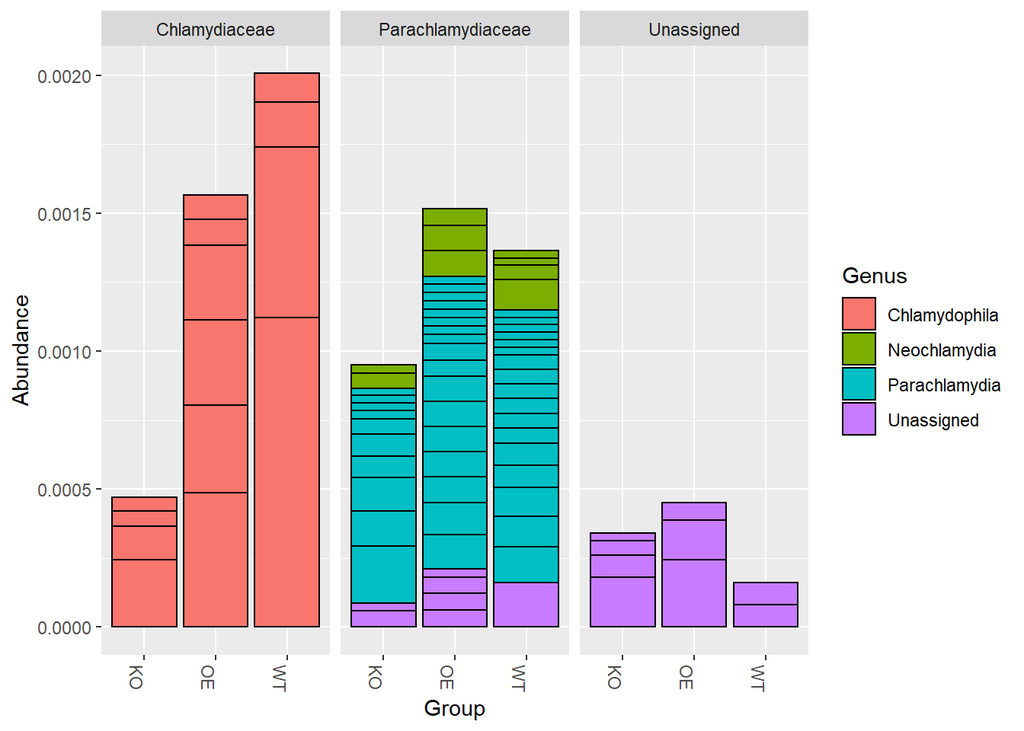

```r
plot_bar(gp.ch, "Group", fill="Genus", facet_grid=~Family)
```

```r
ggsave("./Fig3_Phylum_abundance_bar.png",p2,width = 8,height = 8)
```

### 热图展示微生物的丰度信息

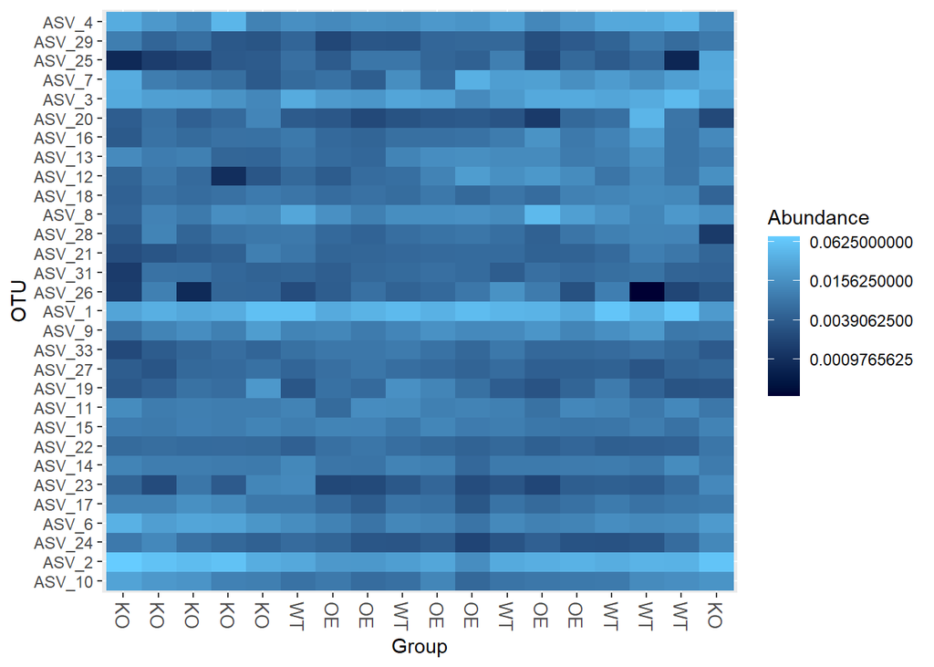

```r
ps_rela = transform_sample_counts(ps, function(x) x/sum(x))
gpt <- subset_taxa(ps_rela, Kingdom=="Bacteria")
gpt <- prune_taxa(names(sort(taxa_sums(ps),TRUE)[1:30]), gpt)
#默认从OTU水平展示丰度热图
plot_heatmap(gpt, sample.label="Group")
```

```r
#--该函数可以使用排序方法对行和列进行排序分析，并且按照结构进行顺序安排。
p3 <- plot_heatmap(gpt, "NMDS", "bray", "Group", "Family") +
  scale_fill_gradientn(colours =colorRampPalette(RColorBrewer::brewer.pal(4,"Set3"))(60))

ggsave("./Fig4_Family_high_abundance_heatmap.png",p3,width = 6,height = 6)
```

### 进化树可视化

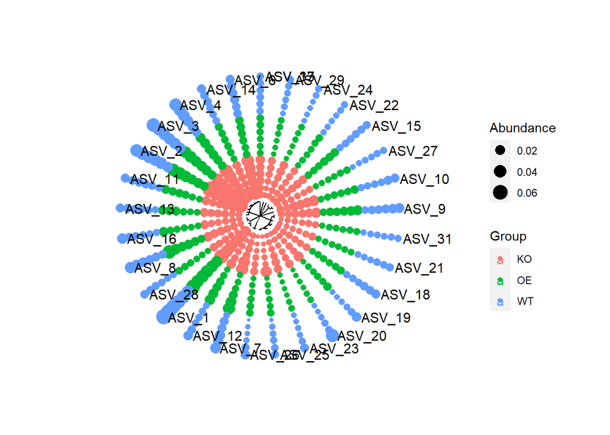

```r
p4 <- plot_tree(gpt,  color="Group", label.tips="taxa_names", ladderize="left",size="abundance", base.spacing=0.8) +
  scale_size_continuous()

plot_tree(gpt,  color="Group", label.tips="taxa_names", ladderize="left",size="abundance", base.spacing=0.5) + coord_polar(theta="y") +
  scale_size_continuous()
```

```r
ggsave("./Fig5_phytree_high_abundance_point.png",p4,width = 8,height = 8)
```

### 微生物网络分析

```r
myTaxa = names(sort(taxa_sums(ps), decreasing = TRUE)[1:50])
ps1 = prune_taxa(myTaxa, ps)
ps1
```

```
## phyloseq-class experiment-level object
## otu_table()   OTU Table:         [ 50 taxa and 18 samples ]
## sample_data() Sample Data:       [ 18 samples by 10 sample variables ]
## tax_table()   Taxonomy Table:    [ 50 taxa by 7 taxonomic ranks ]
## phy_tree()    Phylogenetic Tree: [ 50 tips and 49 internal nodes ]
```

```r
p5 <- plot_net(ps1,type = "taxa",maxdist = 0.6,color = "Phylum")
ggsave("./Fig6_Micro_network.png",p5,width = 8,height = 8)
```

```r
# p0/p4|p1/p4|p2/p3
```

### phyloseq&DEsep2:差异分析

```r
library(DESeq2)
# gm_mean = function(x, na.rm=TRUE){
#   exp(sum(log(x[x > 0]), na.rm=na.rm) / length(x))
# }

diagdds = phyloseq_to_deseq2(ps, ~ Group)
## converting counts to integer mode
# calculate geometric means prior to estimate size factors
gm_mean = function(x, na.rm=TRUE){
  exp(sum(log(x[x > 0]), na.rm=na.rm) / length(x))
}
geoMeans = apply(counts(diagdds), 1, gm_mean)
diagdds = estimateSizeFactors(diagdds, geoMeans = geoMeans)
diagdds = DESeq(diagdds, fitType="local")

res = results(diagdds, cooksCutoff = FALSE)
alpha = 0.01
sigtab = res[which(res$padj < alpha), ]
sigtab = cbind(as(sigtab, "data.frame"), as(tax_table(ps)[rownames(sigtab), ], "matrix"))
head(sigtab)
```

```
##          baseMean log2FoldChange     lfcSE      stat       pvalue        padj
## ASV_174  33.03969      3.4870081 0.8432392  4.135254 3.545625e-05 0.003381463
## ASV_79   82.21388     -0.9250167 0.2133781 -4.335105 1.456906e-05 0.002086737
## ASV_6   625.40881     -1.0358844 0.2333951 -4.438329 9.066008e-06 0.001688091
## ASV_41  154.25212     -1.2313562 0.2991679 -4.115937 3.856089e-05 0.003419066
## ASV_73   85.50976     -1.3770650 0.3129025 -4.400940 1.077831e-05 0.001803533
## ASV_141  42.06084     -1.4928966 0.3334011 -4.477779 7.542366e-06 0.001560432
##          Kingdom         Phylum              Class           Order
## ASV_174 Bacteria Actinobacteria     Actinobacteria Actinomycetales
## ASV_79  Bacteria Proteobacteria Betaproteobacteria Burkholderiales
## ASV_6   Bacteria Proteobacteria Betaproteobacteria Burkholderiales
## ASV_41  Bacteria Proteobacteria Betaproteobacteria Burkholderiales
## ASV_73  Bacteria Proteobacteria Betaproteobacteria Burkholderiales
## ASV_141 Bacteria Proteobacteria Betaproteobacteria Burkholderiales
##                    Family        Genus    Species
## ASV_174 Streptomycetaceae Streptomyces Unassigned
## ASV_79         Unassigned   Unassigned Unassigned
## ASV_6          Unassigned   Unassigned Unassigned
## ASV_41   Oxalobacteraceae   Unassigned Unassigned
## ASV_73   Oxalobacteraceae   Unassigned Unassigned
## ASV_141  Oxalobacteraceae     Massilia Unassigned
```

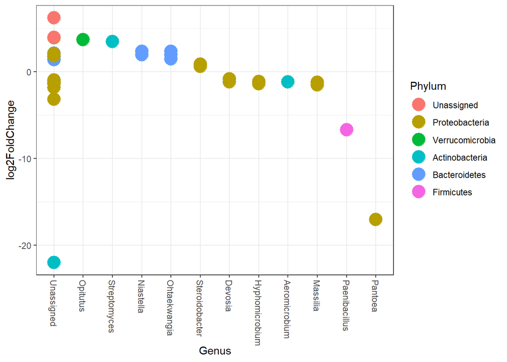

```r
theme_set(theme_bw())
scale_fill_discrete <- function(palname = "Set1", ...) {
    scale_fill_brewer(palette = palname, ...)
}
# Phylum order
x = tapply(sigtab$log2FoldChange, sigtab$Phylum, function(x) max(x))
x = sort(x, TRUE)
sigtab$Phylum = factor(as.character(sigtab$Phylum), levels=names(x))
# Genus order
x = tapply(sigtab$log2FoldChange, sigtab$Genus, function(x) max(x))
x = sort(x, TRUE)
sigtab$Genus = factor(as.character(sigtab$Genus), levels=names(x))
ggplot(sigtab, aes(x=Genus, y=log2FoldChange, color=Phylum)) + geom_point(size=6) +
  theme(axis.text.x = element_text(angle = -90, hjust = 0, vjust=0.5))
```